# LabExperiment1

05 March 2018

# Lab Experiment 1: Single-species Population Growth

## Part I

So far in this course we have focused on single-species population dynamics. We’ve learned about density-independent growth, density-dependent growth, and age- and stage-structured population growth. Now, it’s time to corroborate these models with some real data. That is, we’re going to actually grow a *real* biological population, observe its dyanmics, and use the data to parameterize (i.e., give numeric values to) single-species growth models. (The latter will be Part II of this experiment, next week.) This is a common part of the “modeling cycle,” where analytical models are produced, data is collected on how a population changes, the models are paramteterized, evaluated against one another (if > 1 model), predictions are made, more data is collected, then models are again parameterized and evaluated, and around we go. We must obviously use a fast-growing organism for this experiment, so I chose “the organism that all biologists can agree to love,” *Saccharomyces cerevisiae* (AKA brewer’s yeast, budding yeast, baker’s yeast; hereafter, “yeast”).

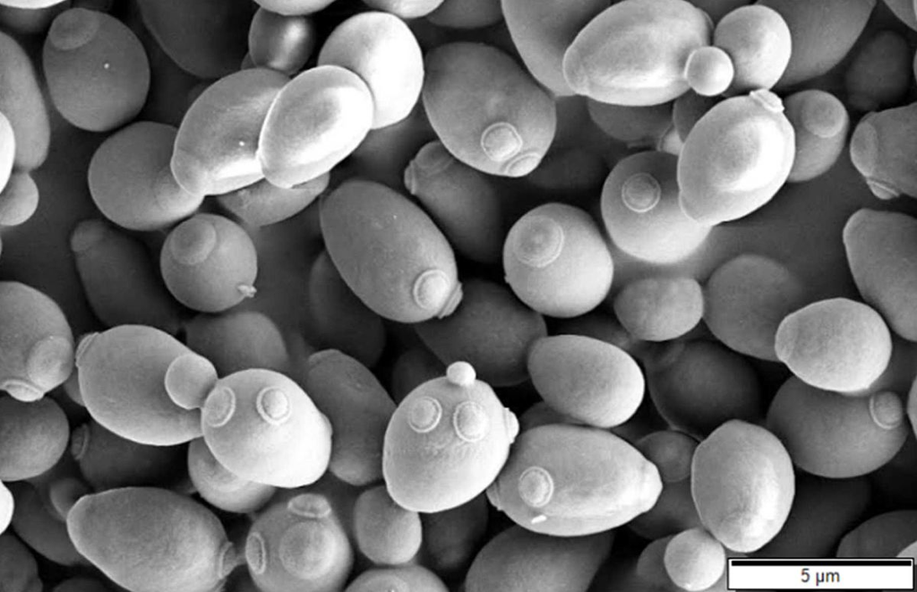

### Some yeast biology

The etymological roots of *Saccharomyces cerevisiae* are, with “Sacchar-” meaning “sugar” (Greek), “-myces” meaning “fungus” (Greek), and “cerevisae” meaning “of beer” (Latin, *como cervesa en Español, no?*). Yeast is a unicellular [Asctomycete](https://en.wikipedia.org/wiki/Ascomycota) fungus. It has both diploid and haploid forms and most commonly reproduces asexually by budding. Budding is virtually the sole process by which the yeast in our experiments proliferate. Depending on conditions, yeast will generally bud between 75 and 150 minutes.

### Yeast growth experiment

We’ll be growing yeast, as mentioned above, to generate data to parameterize and evaluate different single-species populaiton models. It is a relatively straight-forward experiment. Essentially, we sterilize the growth medium, innoculate it with yeast, and count individuals. Below is a list of supplies we’ll be using

- Dehydrated *Saccharomyces cerevisiae* (active dry yeast)
- Growth medium ([YPD from Sigma](https://www.sigmaaldrich.com/technical-documents/articles/biology/Introduction-yeast-media.html))
- Incubator (at 30°C)
- Counting chamber (AKA haemocytometer), Bürker model
- Compound microscope
- Miscellaneous lab supplies

Also, you’ll be working in partners. Here’s R’s sample

```r
set.seed(6174)
matrix(data = sample(c("MB", "CB", "GD", "JJ", "TK", "BK", "HN", "JP", "MP", "JS", "ST", "KV")), ncol = 2)
```

```
##      [,1] [,2]
## [1,] "JP" "GD"
## [2,] "MB" "CB"
## [3,] "TK" "JJ"
## [4,] "KV" "ST"
## [5,] "BK" "JS"
## [6,] "MP" "HN"
```

### Protocol

1. The yeast need to be sampled once per hour for 12 hours because that’s generally the amount of time it takes for them to lag, grow, and reach a maximum population size. Please arrange some time for you and your partner to sample this week, where you divide the sampling between each other. Ideally, one of you would start the culture early in the morning, sample until late in the evening, and continue into the next day if the population has not yet reached a steady, maximum population density. If you need help, please contact me, as I want these to come out well and am willing to help in any way that I can. **Let me know when you plan on running your experiment so I can make myself available if need be.** Find an inoculum tube and label it.
2. When you’re ready to start your experiment, simply pour your inoculum into your (labeled!) flask and swril for 20 seconds.
3. Every hour when you return, measure density by counting the number of yeast. To do this:  
   A. Collect a transfer pipette, a counting chamber, a counter, and coverslip by a microscope (all the materials *ought* to be there.)  
   B. Place the coverslip on the counting chamber, and secure it (no need to screw tightly).  
   C. Collect your culture and bring it by the microscope.  
   D. Swril the yeast and media strongly for about 20 seconds, but try not to let it reach the foil and not to let lots of air mix with the media.  
   E. Remove the foil, use the pipette to draw up at least a drop of your sample (> 1 cm in the pipette neck).  
   F. Place the tip of the pipette on the edge of the coverslip and chamber, then transfer the media under the coverslip via capillary action until the coverslip is filled. (Place pipette on wrapper.)  
   G. Begin counting. Of the nine 1x1mm squares (all outlined by 3 lines, one example in red below), count the 4 corners and middle. Count only the 0.2x0.2mm small squares in each large square (grey in figure below).  
   H. Record your data.  
   I. Cean up by throwing away the pipette and wrapper, unscrewing the counting chamber clips and setting aside, remove and rinse the coverslip, rinse the counting chamber, and **wipe dry with Kimwipes, not paper towels** (we are sharing these, so they need to be dry and the chambers treated delicately).
4. After all the data is recorded, please enter it in the GoogleSheet: [link](https://docs.google.com/spreadsheets/d/1RYBSBM10JPsT47NI2LEA3jEET6VgR54spdvz9ooRLlI/edit?usp=sharing). **Enter in raw data and do not do any calculations before entering**.

### Some remarks on counting

- The yeast will reproducing by budding. This means that there will be many that are in the process of doing so. Typically, we **count a budding yeast if it is 3/4 the size of the parent cell.** Use your best judgement.
- There will be large clumps of yeast. Use your best judgement to estimate how many there are.
- Towards the end of the experiment, there will be lots of yeast to count. If the density is becoming burdensome to count (usually > 200 yeast), then count a subset (e.g., 4 or 8) **Sm. squares counted** to record the number of small squares (grey boxes below) counted. Use your best judgement to determine if or when you will be coutning the small squares.
- If there are **air bubbles** (at later stages these will appear), do not count the small square, count what you can, and record the number of small squares counted in the column “Sm. squares counted” on the data sheet.
- A standard method for **counting cells on the borders** is to choose two of the borders and include anything touching them and not including cells on the other two borders. For this experiment, let’s **count all cells in the small squares, including those touching the right and bottom borders, and don’t count those that are touching the left and upper borderes**. Use your best judgement.

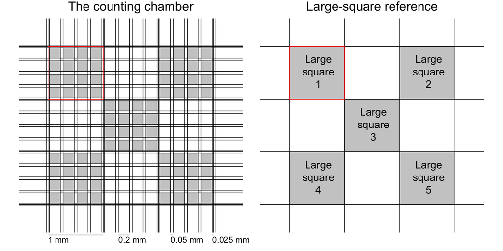

*Doesn’t R make nice diagrams, too?